# cctv

```python
import numpy as np
```

```python
CCTV_Seoul.apply(np.cumsum) #누적합
```

|  | 구별 | 소계 | 2013년도 이전 | 2014년 | 2015년 | 2016년 |
| --- | --- | --- | --- | --- | --- | --- |
| 0 | 강남구 | 2780 | 1292 | 430 | 584 | 932 |
| 1 | 강남구강동구 | 3553 | 1671 | 529 | 739 | 1309 |
| 2 | 강남구강동구강북구 | 4301 | 2040 | 649 | 877 | 1513 |
| 3 | 강남구강동구강북구강서구 | 5185 | 2428 | 907 | 1061 | 1594 |
| 4 | 강남구강동구강북구강서구관악구 | 6681 | 3274 | 1167 | 1451 | 2207 |
| 5 | 강남구강동구강북구강서구관악구광진구 | 7388 | 3847 | 1245 | 1504 | 2381 |
| 6 | 강남구강동구강북구강서구관악구광진구구로구 | 8949 | 4989 | 1418 | 1750 | 2704 |
| 7 | 강남구강동구강북구강서구관악구광진구구로구금천구 | 9964 | 5663 | 1469 | 2019 | 3058 |
| 8 | 강남구강동구강북구강서구관악구광진구구로구금천구노원구 | 11229 | 6205 | 1526 | 2470 | 3574 |
| 9 | 강남구강동구강북구강서구관악구광진구구로구금천구노원구도봉구 | 11714 | 6443 | 1685 | 2512 | 3960 |
| 10 | 강남구강동구강북구강서구관악구광진구구로구금천구노원구도봉구동대문구 | 13008 | 7513 | 1708 | 2710 | 4539 |
| 11 | 강남구강동구강북구강서구관악구광진구구로구금천구노원구도봉구동대문구동작구 | 14099 | 8057 | 2049 | 2813 | 4853 |
| 12 | 강남구강동구강북구강서구관악구광진구구로구금천구노원구도봉구동대문구동작구마포구 | 14673 | 8371 | 2167 | 2982 | 5232 |
| 13 | 강남구강동구강북구강서구관악구광진구구로구금천구노원구도봉구동대문구동작구마포구서대문구 | 15635 | 9215 | 2217 | 3050 | 5524 |
| 14 | 강남구강동구강북구강서구관악구광진구구로구금천구노원구도봉구동대문구동작구마포구서대문구서초구 | 17565 | 10621 | 2374 | 3386 | 5922 |
| 15 | 강남구강동구강북구강서구관악구광진구구로구금천구노원구도봉구동대문구동작구마포구서대문구서초... | 18627 | 11351 | 2465 | 3627 | 6187 |
| 16 | 강남구강동구강북구강서구관악구광진구구로구금천구노원구도봉구동대문구동작구마포구서대문구서초... | 20091 | 12360 | 2543 | 3987 | 6391 |
| 17 | 강남구강동구강북구강서구관악구광진구구로구금천구노원구도봉구동대문구동작구마포구서대문구서초... | 20709 | 12889 | 2564 | 4055 | 6854 |
| 18 | 강남구강동구강북구강서구관악구광진구구로구금천구노원구도봉구동대문구동작구마포구서대문구서초... | 22743 | 14732 | 2706 | 4085 | 7321 |
| 19 | 강남구강동구강북구강서구관악구광진구구로구금천구노원구도봉구동대문구동작구마포구서대문구서초... | 23647 | 15227 | 2920 | 4280 | 7694 |
| 20 | 강남구강동구강북구강서구관악구광진구구로구금천구노원구도봉구동대문구동작구마포구서대문구서초... | 25271 | 16595 | 3138 | 4392 | 8092 |
| 21 | 강남구강동구강북구강서구관악구광진구구로구금천구노원구도봉구동대문구동작구마포구서대문구서초... | 27144 | 17733 | 3362 | 4670 | 8560 |
| 22 | 강남구강동구강북구강서구관악구광진구구로구금천구노원구도봉구동대문구동작구마포구서대문구서초... | 28146 | 18197 | 3676 | 4881 | 9190 |
| 23 | 강남구강동구강북구강서구관악구광진구구로구금천구노원구도봉구동대문구동작구마포구서대문구서초... | 28817 | 18610 | 3866 | 4953 | 9538 |
| 24 | 강남구강동구강북구강서구관악구광진구구로구금천구노원구도봉구동대문구동작구마포구서대문구서초... | 29477 | 19119 | 3987 | 5130 | 9647 |

```python
CCTV_Seoul.loc[0:3,['구별','2015년','2016년']]
```

|  | 구별 | 2015년 | 2016년 |
| --- | --- | --- | --- |
| 0 | 강남구 | 584 | 932 |
| 1 | 강동구 | 155 | 377 |
| 2 | 강북구 | 138 | 204 |
| 3 | 강서구 | 184 | 81 |

```python
CCTV_Seoul.head()
```

|  | 구별 | 소계 | 2013년도 이전 | 2014년 | 2015년 | 2016년 |
| --- | --- | --- | --- | --- | --- | --- |
| 0 | 강남구 | 2780 | 1292 | 430 | 584 | 932 |
| 1 | 강동구 | 773 | 379 | 99 | 155 | 377 |
| 2 | 강북구 | 748 | 369 | 120 | 138 | 204 |
| 3 | 강서구 | 884 | 388 | 258 | 184 | 81 |
| 4 | 관악구 | 1496 | 846 | 260 | 390 | 613 |

```python
# 소계로 정렬
CCTV_Seoul.sort_values(by='소계', ascending=True).head()
```

|  | 구별 | 소계 | 2013년도 이전 | 2014년 | 2015년 | 2016년 |
| --- | --- | --- | --- | --- | --- | --- |
| 9 | 도봉구 | 485 | 238 | 159 | 42 | 386 |
| 12 | 마포구 | 574 | 314 | 118 | 169 | 379 |
| 17 | 송파구 | 618 | 529 | 21 | 68 | 463 |
| 24 | 중랑구 | 660 | 509 | 121 | 177 | 109 |
| 23 | 중구 | 671 | 413 | 190 | 72 | 348 |

```python
CCTV_Seoul.sort_values(by='소계', ascending=True).head()
```

[output not shown]

```python
# 2014~2016 CCTV 증가율을 구해보자
# 증가율 = 2014~2016 CCTV수 / 2013년 이전 CCTV수
CCTV_Seoul['최근증가율'] = (CCTV_Seoul['2016년'] + CCTV_Seoul['2015년'] + CCTV_Seoul['2014년']) / CCTV_Seoul['2013년도 이전'] * 100
CCTV_Seoul.sort_values(by='최근증가율', ascending=False).head()
```

|  | 구별 | 소계 | 2013년도 이전 | 2014년 | 2015년 | 2016년 | 최근증가율 |
| --- | --- | --- | --- | --- | --- | --- | --- |
| 22 | 종로구 | 1002 | 464 | 314 | 211 | 630 | 248.922414 |
| 9 | 도봉구 | 485 | 238 | 159 | 42 | 386 | 246.638655 |
| 12 | 마포구 | 574 | 314 | 118 | 169 | 379 | 212.101911 |
| 8 | 노원구 | 1265 | 542 | 57 | 451 | 516 | 188.929889 |
| 1 | 강동구 | 773 | 379 | 99 | 155 | 377 | 166.490765 |

```python
pop_Seoul.head()
```

|  | 구별 | 인구수 | 한국인 | 외국인 | 고령자 |
| --- | --- | --- | --- | --- | --- |
| 0 | 합계 | 10197604.0 | 9926968.0 | 270636.0 | 1321458.0 |
| 1 | 종로구 | 162820.0 | 153589.0 | 9231.0 | 25425.0 |
| 2 | 중구 | 133240.0 | 124312.0 | 8928.0 | 20764.0 |
| 3 | 용산구 | 244203.0 | 229456.0 | 14747.0 | 36231.0 |
| 4 | 성동구 | 311244.0 | 303380.0 | 7864.0 | 39997.0 |

```python
pop_Seoul.drop([0], inplace=True)
pop_Seoul.head()      #불필요한 합계 0행을 삭제
```

|  | 구별 | 인구수 | 한국인 | 외국인 | 고령자 |
| --- | --- | --- | --- | --- | --- |
| 1 | 종로구 | 162820.0 | 153589.0 | 9231.0 | 25425.0 |
| 2 | 중구 | 133240.0 | 124312.0 | 8928.0 | 20764.0 |
| 3 | 용산구 | 244203.0 | 229456.0 | 14747.0 | 36231.0 |
| 4 | 성동구 | 311244.0 | 303380.0 | 7864.0 | 39997.0 |
| 5 | 광진구 | 372164.0 | 357211.0 | 14953.0 | 42214.0 |

```python
# '구별'컬럼의 unique를 조사하여 어떤 '구'들이 있는지 확인해보자.
pop_Seoul['구별'].unique()
```

```
array(['종로구', '중구', '용산구', '성동구', '광진구', '동대문구', '중랑구', '성북구', '강북구',
       '도봉구', '노원구', '은평구', '서대문구', '마포구', '양천구', '강서구', '구로구', '금천구',
       '영등포구', '동작구', '관악구', '서초구', '강남구', '송파구', '강동구', nan],
      dtype=object)
```

```python
# isnull 명령어를 이용하여 NaN 데이터를 추출해보자.
pop_Seoul[pop_Seoul['구별'].isnull()]
```

|  | 구별 | 인구수 | 한국인 | 외국인 | 고령자 |
| --- | --- | --- | --- | --- | --- |
| 26 | NaN | NaN | NaN | NaN | NaN |

```python
# NaN에 해당하는 26번 row를 삭제해주자.
pop_Seoul.drop([26], inplace=True)
pop_Seoul.head()
```

|  | 구별 | 인구수 | 한국인 | 외국인 | 고령자 |
| --- | --- | --- | --- | --- | --- |
| 1 | 종로구 | 162820.0 | 153589.0 | 9231.0 | 25425.0 |
| 2 | 중구 | 133240.0 | 124312.0 | 8928.0 | 20764.0 |
| 3 | 용산구 | 244203.0 | 229456.0 | 14747.0 | 36231.0 |
| 4 | 성동구 | 311244.0 | 303380.0 | 7864.0 | 39997.0 |
| 5 | 광진구 | 372164.0 | 357211.0 | 14953.0 | 42214.0 |

```python
# 구별 '외국인비율'과 '고령자비율'을 계산해보자.
pop_Seoul['외국인비율'] = pop_Seoul['외국인'] / pop_Seoul['인구수'] * 100
pop_Seoul['고령자비율'] = pop_Seoul['고령자'] / pop_Seoul['인구수'] * 100
pop_Seoul.head()
```

|  | 구별 | 인구수 | 한국인 | 외국인 | 고령자 | 외국인비율 | 고령자비율 |
| --- | --- | --- | --- | --- | --- | --- | --- |
| 1 | 종로구 | 162820.0 | 153589.0 | 9231.0 | 25425.0 | 5.669451 | 15.615404 |
| 2 | 중구 | 133240.0 | 124312.0 | 8928.0 | 20764.0 | 6.700690 | 15.583909 |
| 3 | 용산구 | 244203.0 | 229456.0 | 14747.0 | 36231.0 | 6.038828 | 14.836427 |
| 4 | 성동구 | 311244.0 | 303380.0 | 7864.0 | 39997.0 | 2.526635 | 12.850689 |
| 5 | 광진구 | 372164.0 | 357211.0 | 14953.0 | 42214.0 | 4.017852 | 11.342849 |

```python
# 인구수 정렬
pop_Seoul.sort_values(by='인구수', ascending=False).head(5)
```

[output not shown]

```python
# 구별 '한국인비율'을 계산해보자.
pop_Seoul['한국인비율'] = pop_Seoul['한국인'] / pop_Seoul['인구수'] * 100

pop_Seoul.head()
```

|  | 구별 | 인구수 | 한국인 | 외국인 | 고령자 | 외국인비율 | 고령자비율 | 한국인비율 |
| --- | --- | --- | --- | --- | --- | --- | --- | --- |
| 1 | 종로구 | 162820.0 | 153589.0 | 9231.0 | 25425.0 | 5.669451 | 15.615404 | 94.330549 |
| 2 | 중구 | 133240.0 | 124312.0 | 8928.0 | 20764.0 | 6.700690 | 15.583909 | 93.299310 |
| 3 | 용산구 | 244203.0 | 229456.0 | 14747.0 | 36231.0 | 6.038828 | 14.836427 | 93.961172 |
| 4 | 성동구 | 311244.0 | 303380.0 | 7864.0 | 39997.0 | 2.526635 | 12.850689 | 97.473365 |
| 5 | 광진구 | 372164.0 | 357211.0 | 14953.0 | 42214.0 | 4.017852 | 11.342849 | 95.982148 |

```python
pop_Seoul.sort_values(by='고령자', ascending=False).head()
```

|  | 구별 | 인구수 | 한국인 | 외국인 | 고령자 | 외국인비율 | 고령자비율 | 한국인비율 |
| --- | --- | --- | --- | --- | --- | --- | --- | --- |
| 16 | 강서구 | 603772.0 | 597248.0 | 6524.0 | 72548.0 | 1.080540 | 12.015794 | 98.919460 |
| 24 | 송파구 | 667483.0 | 660584.0 | 6899.0 | 72506.0 | 1.033584 | 10.862599 | 98.966416 |
| 12 | 은평구 | 494388.0 | 489943.0 | 4445.0 | 72334.0 | 0.899091 | 14.631019 | 99.100909 |
| 11 | 노원구 | 569384.0 | 565565.0 | 3819.0 | 71941.0 | 0.670725 | 12.634883 | 99.329275 |
| 21 | 관악구 | 525515.0 | 507203.0 | 18312.0 | 68082.0 | 3.484582 | 12.955291 | 96.515418 |

```python
df1 = pd.DataFrame({'A': ['A0', 'A1', 'A2', 'A3'],
                    'B': ['B0', 'B1', 'B2', 'B3'],
                    'C': ['C0', 'C1', 'C2', 'C3'],
                    'D': ['D0', 'D1', 'D2', 'D3']},
                   index=[0, 1, 2, 3])
df2 = pd.DataFrame({'A': ['A4', 'A5', 'A6', 'A7'],
                    'B': ['B4', 'B5', 'B6', 'B7'],
                    'C': ['C4', 'C5', 'C6', 'C7'],
                    'D': ['D4', 'D5', 'D6', 'D7']},
                   index=[4, 5, 6, 7])
df3 = pd.DataFrame({'A': ['A8', 'A9', 'A10', 'A11'],
                    'B': ['B8', 'B9', 'B10', 'B11'],
                    'C': ['C8', 'C9', 'C10', 'C11'],
                    'D': ['D8', 'D9', 'D10', 'D11']},
                   index=[8, 9, 10, 11])
```

```python
df1
```

|  | A | B | C | D |
| --- | --- | --- | --- | --- |
| 0 | A0 | B0 | C0 | D0 |
| 1 | A1 | B1 | C1 | D1 |
| 2 | A2 | B2 | C2 | D2 |
| 3 | A3 | B3 | C3 | D3 |

```python
# 열방향으로 단순히 합치는 기능
result = pd.concat([df1, df2, df3])
result
```

|  | A | B | C | D |
| --- | --- | --- | --- | --- |
| 0 | A0 | B0 | C0 | D0 |
| 1 | A1 | B1 | C1 | D1 |
| 2 | A2 | B2 | C2 | D2 |
| 3 | A3 | B3 | C3 | D3 |
| 4 | A4 | B4 | C4 | D4 |
| 5 | A5 | B5 | C5 | D5 |
| 6 | A6 | B6 | C6 | D6 |
| 7 | A7 | B7 | C7 | D7 |
| 8 | A8 | B8 | C8 | D8 |
| 9 | A9 | B9 | C9 | D9 |
| 10 | A10 | B10 | C10 | D10 |
| 11 | A11 | B11 | C11 | D11 |

```python
# concat에 옵션을 넣어보자.
# key 옵션을 넣으면 다중 index가 되어 DataFrame별로 level을 형성한다.
result = pd.concat([df1, df2, df3], keys=['x', 'y', 'z'])
result
```

|  |  | A | B | C | D |
| --- | --- | --- | --- | --- | --- |
| x | 0 | A0 | B0 | C0 | D0 |
|  | 1 | A1 | B1 | C1 | D1 |
|  | 2 | A2 | B2 | C2 | D2 |
|  | 3 | A3 | B3 | C3 | D3 |
| y | 4 | A4 | B4 | C4 | D4 |
|  | 5 | A5 | B5 | C5 | D5 |
|  | 6 | A6 | B6 | C6 | D6 |
|  | 7 | A7 | B7 | C7 | D7 |
| z | 8 | A8 | B8 | C8 | D8 |
|  | 9 | A9 | B9 | C9 | D9 |
|  | 10 | A10 | B10 | C10 | D10 |
|  | 11 | A11 | B11 | C11 | D11 |

```python
result.index
```

```
MultiIndex([('x',  0),
            ('x',  1),
            ('x',  2),
            ('x',  3),
            ('y',  4),
            ('y',  5),
            ('y',  6),
            ('y',  7),
            ('z',  8),
            ('z',  9),
            ('z', 10),
            ('z', 11)],
           )
```

```python
# 새로운 DataFrame을 만들어 axis 옵션을 사용하여 concat시켜보자.
df4 = pd.DataFrame({'B': ['B2', 'B3', 'B6', 'B7'],
                    'C': ['D2', 'D3', 'D6', 'D7'],
                    'F': ['F2', 'F3', 'F6', 'F7']},
                   index=[2, 3, 6, 7])
result = pd.concat([df1, df4], axis=1)
```

```python
result
```

|  | A | B | C | D | B | C | F |
| --- | --- | --- | --- | --- | --- | --- | --- |
| 0 | A0 | B0 | C0 | D0 | NaN | NaN | NaN |
| 1 | A1 | B1 | C1 | D1 | NaN | NaN | NaN |
| 2 | A2 | B2 | C2 | D2 | B2 | D2 | F2 |
| 3 | A3 | B3 | C3 | D3 | B3 | D3 | F3 |
| 6 | NaN | NaN | NaN | NaN | B6 | D6 | F6 |
| 7 | NaN | NaN | NaN | NaN | B7 | D7 | F7 |

```python
#concat의 join 옵션을 사용해보자.
result = pd.concat([df1, df4], axis=1, join='inner')
result
```

|  | A | B | C | D | B | C | F |
| --- | --- | --- | --- | --- | --- | --- | --- |
| 2 | A2 | B2 | C2 | D2 | B2 | D2 | F2 |
| 3 | A3 | B3 | C3 | D3 | B3 | D3 | F3 |

```python
#concat의 join_axes 옵션을 사용해보자.
result = pd.concat([df1, df4], axis=1, join_axes=[df1.index])
result
```

[output not shown]

```python
# ignore_index=True 옵션을 사용해보자.
# index를 무시하고 합친 후 다시 index를 부여
result = pd.concat([df1, df4], ignore_index=True)
result
```

|  | A | B | C | D | F |
| --- | --- | --- | --- | --- | --- |
| 0 | A0 | B0 | C0 | D0 | NaN |
| 1 | A1 | B1 | C1 | D1 | NaN |
| 2 | A2 | B2 | C2 | D2 | NaN |
| 3 | A3 | B3 | C3 | D3 | NaN |
| 4 | NaN | B2 | D2 | NaN | F2 |
| 5 | NaN | B3 | D3 | NaN | F3 |
| 6 | NaN | B6 | D6 | NaN | F6 |
| 7 | NaN | B7 | D7 | NaN | F7 |

```python
left = pd.DataFrame({'key': ['k0', 'k4', 'k2', 'k3'],
                     'A': ['A0', 'A1', 'A2', 'A3'],
                     'B': ['B0', 'B1', 'B2', 'B3']})
right = pd.DataFrame({'key': ['k0', 'k1', 'k2', 'k3'],
                     'C': ['C0', 'C1', 'C2', 'C3'],
                     'D': ['D0', 'D1', 'D2', 'D3']})
```

```python
# merge 명령에서 merge 기순을 설정하는 on 옵션으로 합치면 공통된 key에 대해서만 합치게 된다.
pd.merge(left, right, on='key')
```

|  | key | A | B | C | D |
| --- | --- | --- | --- | --- | --- |
| 0 | k0 | A0 | B0 | C0 | D0 |
| 1 | k2 | A2 | B2 | C2 | D2 |
| 2 | k3 | A3 | B3 | C3 | D3 |

```python
# how 옵션을 사용하여 합치는 두 데이터를 한쪽 데이터를 기준으로 합칠 수도 있다.
# 왼쪽 기주운~
pd.merge(left, right, how='left', on='key')
```

|  | key | A | B | C | D |
| --- | --- | --- | --- | --- | --- |
| 0 | k0 | A0 | B0 | C0 | D0 |
| 1 | k4 | A1 | B1 | NaN | NaN |
| 2 | k2 | A2 | B2 | C2 | D2 |
| 3 | k3 | A3 | B3 | C3 | D3 |

```python
left
```

|  | key | A | B |
| --- | --- | --- | --- |
| 0 | k0 | A0 | B0 |
| 1 | k4 | A1 | B1 |
| 2 | k2 | A2 | B2 |
| 3 | k3 | A3 | B3 |

```python
right
```

|  | key | C | D |
| --- | --- | --- | --- |
| 0 | k0 | C0 | D0 |
| 1 | k1 | C1 | D1 |
| 2 | k2 | C2 | D2 |
| 3 | k3 | C3 | D3 |

```python
pd.merge(left,right,on='key')
```

|  | key | A | B | C | D |
| --- | --- | --- | --- | --- | --- |
| 0 | k0 | A0 | B0 | C0 | D0 |
| 1 | k2 | A2 | B2 | C2 | D2 |
| 2 | k3 | A3 | B3 | C3 | D3 |

```python
# 오른쪽 기준~
pd.merge(left, right, how='right', on='key')
```

|  | key | A | B | C | D |
| --- | --- | --- | --- | --- | --- |
| 0 | k0 | A0 | B0 | C0 | D0 |
| 1 | k2 | A2 | B2 | C2 | D2 |
| 2 | k3 | A3 | B3 | C3 | D3 |
| 3 | k1 | NaN | NaN | C1 | D1 |

```python
# how의 값을 outer로 하면 merge한 데이터 결과 모두를 가진다. 합집합
pd.merge(left, right, how='outer', on='key')
```

|  | key | A | B | C | D |
| --- | --- | --- | --- | --- | --- |
| 0 | k0 | A0 | B0 | C0 | D0 |
| 1 | k4 | A1 | B1 | NaN | NaN |
| 2 | k2 | A2 | B2 | C2 | D2 |
| 3 | k3 | A3 | B3 | C3 | D3 |
| 4 | k1 | NaN | NaN | C1 | D1 |

```python
# outer와 반대의 옵션인 inner 옵션 교집합
pd.merge(left, right, how='inner', on='key')
```

|  | key | A | B | C | D |
| --- | --- | --- | --- | --- | --- |
| 0 | k0 | A0 | B0 | C0 | D0 |
| 1 | k2 | A2 | B2 | C2 | D2 |
| 2 | k3 | A3 | B3 | C3 | D3 |

```python
# merge를 사용하여 병합시켜 보자.
data_result = pd.merge(CCTV_Seoul, pop_Seoul, on='구별')
data_result.head()
```

|  | 구별 | 소계 | 2013년도 이전 | 2014년 | 2015년 | 2016년 | 최근증가율 | 인구수 | 한국인 | 외국인 | 고령자 | 외국인비율 | 고령자비율 | 한국인비율 |
| --- | --- | --- | --- | --- | --- | --- | --- | --- | --- | --- | --- | --- | --- | --- |
| 0 | 강남구 | 2780 | 1292 | 430 | 584 | 932 | 150.619195 | 570500.0 | 565550.0 | 4950.0 | 63167.0 | 0.867660 | 11.072217 | 99.132340 |
| 1 | 강동구 | 773 | 379 | 99 | 155 | 377 | 166.490765 | 453233.0 | 449019.0 | 4214.0 | 54622.0 | 0.929765 | 12.051638 | 99.070235 |
| 2 | 강북구 | 748 | 369 | 120 | 138 | 204 | 125.203252 | 330192.0 | 326686.0 | 3506.0 | 54813.0 | 1.061806 | 16.600342 | 98.938194 |
| 3 | 강서구 | 884 | 388 | 258 | 184 | 81 | 134.793814 | 603772.0 | 597248.0 | 6524.0 | 72548.0 | 1.080540 | 12.015794 | 98.919460 |
| 4 | 관악구 | 1496 | 846 | 260 | 390 | 613 | 149.290780 | 525515.0 | 507203.0 | 18312.0 | 68082.0 | 3.484582 | 12.955291 | 96.515418 |

```python
# 의미 없는 컬럼을 del 명령어를 이용하여 지우도록 하자.
# 일반적으로 행을 삭제할때는 drop을 열을 삭제할때는 del을 사용한다.
del data_result['2013년도 이전']
del data_result['2014년']
del data_result['2015년']
del data_result['2016년']
data_result.head()
```

|  | 구별 | 소계 | 최근증가율 | 인구수 | 한국인 | 외국인 | 고령자 | 외국인비율 | 고령자비율 | 한국인비율 |
| --- | --- | --- | --- | --- | --- | --- | --- | --- | --- | --- |
| 0 | 강남구 | 2780 | 150.619195 | 570500.0 | 565550.0 | 4950.0 | 63167.0 | 0.867660 | 11.072217 | 99.132340 |
| 1 | 강동구 | 773 | 166.490765 | 453233.0 | 449019.0 | 4214.0 | 54622.0 | 0.929765 | 12.051638 | 99.070235 |
| 2 | 강북구 | 748 | 125.203252 | 330192.0 | 326686.0 | 3506.0 | 54813.0 | 1.061806 | 16.600342 | 98.938194 |
| 3 | 강서구 | 884 | 134.793814 | 603772.0 | 597248.0 | 6524.0 | 72548.0 | 1.080540 | 12.015794 | 98.919460 |
| 4 | 관악구 | 1496 | 149.290780 | 525515.0 | 507203.0 | 18312.0 | 68082.0 | 3.484582 | 12.955291 | 96.515418 |

```python
# 그래프 그릴 것을 고려하여 index를 구로 고치자.
data_result.set_index('구별', inplace=True)
data_result.head()
```

| 구별 | 소계 | 최근증가율 | 인구수 | 한국인 | 외국인 | 고령자 | 외국인비율 | 고령자비율 | 한국인비율 |
| --- | --- | --- | --- | --- | --- | --- | --- | --- | --- |
| 강남구 | 2780 | 150.619195 | 570500.0 | 565550.0 | 4950.0 | 63167.0 | 0.867660 | 11.072217 | 99.132340 |
| 강동구 | 773 | 166.490765 | 453233.0 | 449019.0 | 4214.0 | 54622.0 | 0.929765 | 12.051638 | 99.070235 |
| 강북구 | 748 | 125.203252 | 330192.0 | 326686.0 | 3506.0 | 54813.0 | 1.061806 | 16.600342 | 98.938194 |
| 강서구 | 884 | 134.793814 | 603772.0 | 597248.0 | 6524.0 | 72548.0 | 1.080540 | 12.015794 | 98.919460 |
| 관악구 | 1496 | 149.290780 | 525515.0 | 507203.0 | 18312.0 | 68082.0 | 3.484582 | 12.955291 | 96.515418 |

다양한 접근은 개인적으로 해보고, 고령자비율, 외국인비율, 인구수 중에서 무슨 데이터와 CCTV를 비교할지 정해보겠다. 그렇게 하는 가장 단순한 작업이 상관계수를 조사하는 것이다. 상관계수의 절대값이 클수록 두 데이터는 관계가 있다고 볼 수 있다. 먼저 numpy의 corrcoef명령어 를 사용하여 상관계수를 구해보고 상관계수가 가장 큰 값인 데이터를 비교하겠다.

```python
np.corrcoef(data_result['고령자비율'], data_result['소계'])
```

```
array([[ 1.        , -0.28078554],
       [-0.28078554,  1.        ]])
```

CCTV 개수와 고령자 비율은 약한 음의 상관관계임을 알 수 있다.

```python
np.corrcoef(data_result['외국인비율'], data_result['소계'])
```

```
array([[ 1.        , -0.13607433],
       [-0.13607433,  1.        ]])
```

외국인의 비율과는 큰 의미가 없다고 할 수 있다.

```python
np.corrcoef(data_result['인구수'], data_result['소계'])
```

```
array([[1.        , 0.30634228],
       [0.30634228, 1.        ]])
```

인구수와는 약한 상관관계가 있다고 볼 수 있다. 이김에 CCTV와 인구수의 관계를 좀 더 들여다보자.

```python
data_result.sort_values(by='소계', ascending=False).head()
```

| 구별 | 소계 | 최근증가율 | 인구수 | 한국인 | 외국인 | 고령자 | 외국인비율 | 고령자비율 | 한국인비율 |
| --- | --- | --- | --- | --- | --- | --- | --- | --- | --- |
| 강남구 | 2780 | 150.619195 | 570500.0 | 565550.0 | 4950.0 | 63167.0 | 0.867660 | 11.072217 | 99.132340 |
| 양천구 | 2034 | 34.671731 | 479978.0 | 475949.0 | 4029.0 | 52975.0 | 0.839413 | 11.036964 | 99.160587 |
| 서초구 | 1930 | 63.371266 | 450310.0 | 445994.0 | 4316.0 | 51733.0 | 0.958451 | 11.488308 | 99.041549 |
| 은평구 | 1873 | 85.237258 | 494388.0 | 489943.0 | 4445.0 | 72334.0 | 0.899091 | 14.631019 | 99.100909 |
| 용산구 | 1624 | 53.216374 | 244203.0 | 229456.0 | 14747.0 | 36231.0 | 6.038828 | 14.836427 | 93.961172 |

```python
data_result.sort_values(by='인구수', ascending=False).head()
```

| 구별 | 소계 | 최근증가율 | 인구수 | 한국인 | 외국인 | 고령자 | 외국인비율 | 고령자비율 | 한국인비율 |
| --- | --- | --- | --- | --- | --- | --- | --- | --- | --- |
| 송파구 | 618 | 104.347826 | 667483.0 | 660584.0 | 6899.0 | 72506.0 | 1.033584 | 10.862599 | 98.966416 |
| 강서구 | 884 | 134.793814 | 603772.0 | 597248.0 | 6524.0 | 72548.0 | 1.080540 | 12.015794 | 98.919460 |
| 강남구 | 2780 | 150.619195 | 570500.0 | 565550.0 | 4950.0 | 63167.0 | 0.867660 | 11.072217 | 99.132340 |
| 노원구 | 1265 | 188.929889 | 569384.0 | 565565.0 | 3819.0 | 71941.0 | 0.670725 | 12.634883 | 99.329275 |
| 관악구 | 1496 | 149.290780 | 525515.0 | 507203.0 | 18312.0 | 68082.0 | 3.484582 | 12.955291 | 96.515418 |

```python
import matplotlib.pyplot as plt
%matplotlib inline
# 그래프의 결과를 출력세션에 나타나게 한다.
```

```python
# 한글 폰트 지원
import platform

from matplotlib import font_manager, rc
plt.rcParams['axes.unicode_minus']=False

if platform.system() == 'Darwin':
    rc('font', family='AppleGothic')
elif platform.system() == 'Windows':
    path = 'c:/Windows/Fonts/malgun.ttf'
    font_name = font_manager.FontProperties(fname=path).get_name()
    rc('font', family=font_name)
else:
    print('Unkown system... sorry~~~~')
```

```python
# 결과 변수 다시 확인
data_result.head()
```

| 구별 | 소계 | 최근증가율 | 인구수 | 한국인 | 외국인 | 고령자 | 외국인비율 | 고령자비율 | 한국인비율 |
| --- | --- | --- | --- | --- | --- | --- | --- | --- | --- |
| 강남구 | 2780 | 150.619195 | 570500.0 | 565550.0 | 4950.0 | 63167.0 | 0.867660 | 11.072217 | 99.132340 |
| 강동구 | 773 | 166.490765 | 453233.0 | 449019.0 | 4214.0 | 54622.0 | 0.929765 | 12.051638 | 99.070235 |
| 강북구 | 748 | 125.203252 | 330192.0 | 326686.0 | 3506.0 | 54813.0 | 1.061806 | 16.600342 | 98.938194 |
| 강서구 | 884 | 134.793814 | 603772.0 | 597248.0 | 6524.0 | 72548.0 | 1.080540 | 12.015794 | 98.919460 |
| 관악구 | 1496 | 149.290780 | 525515.0 | 507203.0 | 18312.0 | 68082.0 | 3.484582 | 12.955291 | 96.515418 |

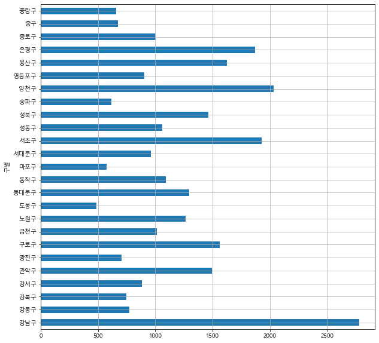

```python
# pandas 데이터 뒤에 plot 명령어를 붙인다
# kind='barh' 수평bar 그래프.
data_result['소계'].plot(kind='barh', grid=True, figsize=(10,10))
plt.show()
```

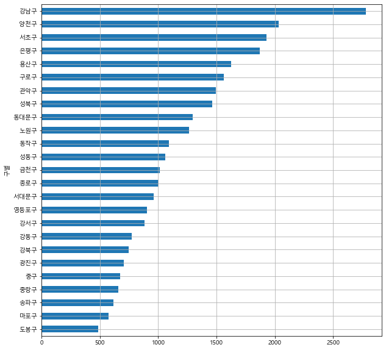

```python
# 위 그림은 큰 의미를 찾기 어렵다. 정렬을 통해 좀 더 보기 좋게 바꿔보자.
data_result['소계'].sort_values().plot(kind='barh', grid=True, figsize=(10,10))

plt.show()
```

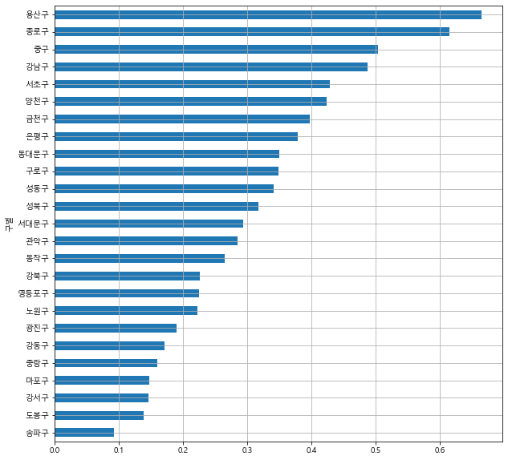

```python
data_result['CCTV비율'] = data_result['소계'] / data_result['인구수'] *100
data_result['CCTV비율'].sort_values().plot(kind='barh', grid=True, figsize=(10,10))

plt.show()
```

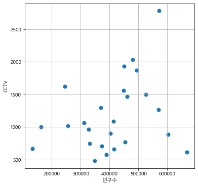

```python
# 마커 s =50
plt.figure(figsize=(6,6))
plt.scatter(data_result['인구수'], data_result['소계'], s = 50)
plt.xlabel('인구수')
plt.ylabel('CCTV')
plt.grid()
plt.show()
```

```python
# 위 그래프를 대표하는 직선을 하나 그려보자.
#아까 CCTV와 인구수는 양의 상관관계가 있다는 것을 보였었다.

#numpy의 polyfit 명령으로 손쉽게 직선을 만들 수 있다.

fp1 = np.polyfit(data_result['인구수'], data_result['소계'], 1)
fp1
```

```
array([1.30916415e-03, 6.45066497e+02])
```

```python
f1 = np.poly1d(fp1)                       # y축 데이터
fx = np.linspace(100000, 700000, 100)     # x축 데이터
```

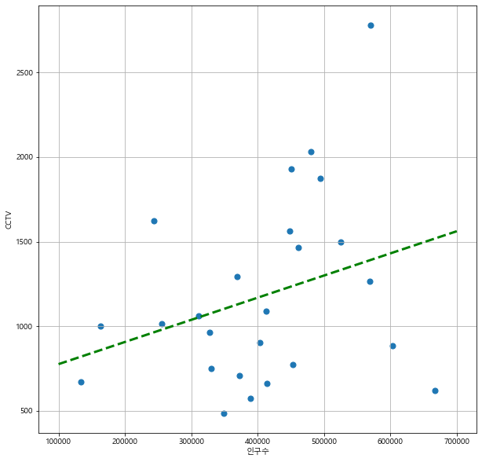

```python
plt.figure(figsize=(10,10))
plt.scatter(data_result['인구수'], data_result['소계'], s=50)
plt.plot(fx, f1(fx), ls='dashed', lw=3, color='g')
plt.xlabel('인구수')
plt.ylabel('CCTV')
plt.grid()
plt.show()
```

여기에 두 가지 방법을 넣고 싶다. 하나는 직선이 이 전체 데이터의 대표 값 역할을 한다면

이 경향성에서 멀이 있는 구는 이름을 나타나도록 하고 싶다는 것 직선에서 멀어질수록 다른 색을 내타내는 것

```python
# 오차를 계산할 수 있는 코드를 만들고 오차가 큰 순으로 데이터를 정렬해서 다시 저장하자.
fp1 = np.polyfit(data_result['인구수'], data_result['소계'], 1)

f1 = np.poly1d(fp1)
fx = np.linspace(100000, 700000, 100)

data_result['오차'] = np.abs(data_result['소계'] - f1(data_result['인구수']))

df_sort = data_result.sort_values(by='오차', ascending=False)
df_sort.head()
```

| 구별 | 소계 | 최근증가율 | 인구수 | 한국인 | 외국인 | 고령자 | 외국인비율 | 고령자비율 | 한국인비율 | CCTV비율 | 오차 |
| --- | --- | --- | --- | --- | --- | --- | --- | --- | --- | --- | --- |
| 강남구 | 2780 | 150.619195 | 570500.0 | 565550.0 | 4950.0 | 63167.0 | 0.867660 | 11.072217 | 99.132340 | 0.487292 | 1388.055355 |
| 송파구 | 618 | 104.347826 | 667483.0 | 660584.0 | 6899.0 | 72506.0 | 1.033584 | 10.862599 | 98.966416 | 0.092587 | 900.911312 |
| 양천구 | 2034 | 34.671731 | 479978.0 | 475949.0 | 4029.0 | 52975.0 | 0.839413 | 11.036964 | 99.160587 | 0.423769 | 760.563512 |
| 서초구 | 1930 | 63.371266 | 450310.0 | 445994.0 | 4316.0 | 51733.0 | 0.958451 | 11.488308 | 99.041549 | 0.428594 | 695.403794 |
| 용산구 | 1624 | 53.216374 | 244203.0 | 229456.0 | 14747.0 | 36231.0 | 6.038828 | 14.836427 | 93.961172 | 0.665020 | 659.231690 |

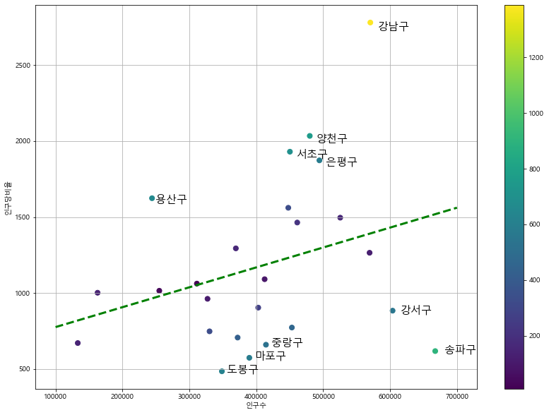

```python
# 이제 텍스트와 colormap을 입히자.
plt.figure(figsize=(14, 10))
plt.scatter(data_result['인구수'], data_result['소계'],
            c=data_result['오차'], s=50)
plt.plot(fx, f1(fx), ls='dashed', lw=3, color='g')

for n in range(10):
    plt.text(df_sort['인구수'][n]*1.02, df_sort['소계'][n]*0.98,
            df_sort.index[n], fontsize=15)

plt.xlabel('인구수')
plt.ylabel('인구당비율')

plt.colorbar()
plt.grid()
plt.show()
```